# Course Project

WYL

November 13, 2018

## 1. Background

Using devices such as Jawbone Up, Nike FuelBand, and Fitbit it is now possible to collect a large amount of data about personal activity relatively inexpensively. These type of devices are part of the quantified self movement a group of enthusiasts who take measurements about themselves regularly to improve their health, to find patterns in their behavior, or because they are tech geeks. One thing that people regularly do is quantify how much of a particular activity they do, but they rarely quantify how well they do it. In this project, your goal will be to use data from accelerometers on the belt, forearm, arm, and dumbell of 6 participants.They were asked to perform barbell lifts correctly and incorrectly in 5 different ways. More information is available from the website here: http://groupware.les.inf.puc-rio.br/har(see the section on the Weight Lifting Exercise Dataset).

## 2. Load Packages

```r
# data wrangling
library(tidyverse)
library(stringr)
library(caTools)
library(lubridate)

# data assessment/visualizations
library(ggplot2)
library(gridExtra)
library(corrplot)
library(knitr)
library(caret)
library(randomForest)
```

## 3. Load data and Clean data

### 3.1 Read dataset

The dataset I am using in this course project is the Human Activity Recognition Dataset. The data can be downloaded from following link:  
training set : https://d396qusza40orc.cloudfront.net/predmachlearn/pml-training.csv  
testing set: https://d396qusza40orc.cloudfront.net/predmachlearn/pml-testing.csv

```r
train <- read_csv('./pml-training.csv') %>%
        mutate(set = 'train')
test <- read_csv('./pml-testing.csv') %>%
        select(-problem_id) %>%
        mutate(classe = NA) %>%
        mutate(set = 'test')
# rbind train and test
full <- bind_rows(train, test)
```

### 3.2 Check dataset

Check dataset structure and dimensions as follow:

```r
# check data
glimpse(full)
```

```
Observations: 19,642
Variables: 161
$ X1                       <int> 1, 2, 3, 4, 5, 6, 7, 8, 9, 10, 11, 12...
$ user_name                <chr> "carlitos", "carlitos", "carlitos", "...
$ raw_timestamp_part_1     <int> 1323084231, 1323084231, 1323084231, 1...
$ raw_timestamp_part_2     <int> 788290, 808298, 820366, 120339, 19632...
$ cvtd_timestamp           <chr> "05/12/2011 11:23", "05/12/2011 11:23...
$ new_window               <chr> "no", "no", "no", "no", "no", "no", "...
$ num_window               <int> 11, 11, 11, 12, 12, 12, 12, 12, 12, 1...
$ roll_belt                <dbl> 1.41, 1.41, 1.42, 1.48, 1.48, 1.45, 1...
$ pitch_belt               <dbl> 8.07, 8.07, 8.07, 8.05, 8.07, 8.06, 8...
$ yaw_belt                 <dbl> -94.4, -94.4, -94.4, -94.4, -94.4, -9...
$ total_accel_belt         <int> 3, 3, 3, 3, 3, 3, 3, 3, 3, 3, 3, 3, 3...
$ kurtosis_roll_belt       <chr> NA, NA, NA, NA, NA, NA, NA, NA, NA, N...
$ kurtosis_picth_belt      <chr> NA, NA, NA, NA, NA, NA, NA, NA, NA, N...
```

[output cut: 148 more lines]

```r
# dataset dimensions
dim(full)
```

```
[1] 19642   161
```

```r
# check first 6 lines
head(full)
```

```
# A tibble: 6 x 161
     X1 user_name raw_timestamp_part_1 raw_timestamp_part… cvtd_timestamp
  <int> <chr>                    <int>               <int> <chr>
1     1 carlitos            1323084231              788290 05/12/2011 11:…
2     2 carlitos            1323084231              808298 05/12/2011 11:…
3     3 carlitos            1323084231              820366 05/12/2011 11:…
4     4 carlitos            1323084232              120339 05/12/2011 11:…
5     5 carlitos            1323084232              196328 05/12/2011 11:…
6     6 carlitos            1323084232              304277 05/12/2011 11:…
# ... with 156 more variables: new_window <chr>, num_window <int>,
#   roll_belt <dbl>, pitch_belt <dbl>, yaw_belt <dbl>,
#   total_accel_belt <int>, kurtosis_roll_belt <chr>,
#   kurtosis_picth_belt <chr>, kurtosis_yaw_belt <chr>,
#   skewness_roll_belt <chr>, skewness_roll_belt.1 <chr>,
#   skewness_yaw_belt <chr>, max_roll_belt <dbl>, max_picth_belt <int>,
#   max_yaw_belt <chr>, min_roll_belt <dbl>, min_pitch_belt <int>,
#   min_yaw_belt <chr>, amplitude_roll_belt <dbl>,
#   amplitude_pitch_belt <int>, amplitude_yaw_belt <chr>,
#   var_total_accel_belt <dbl>, avg_roll_belt <dbl>,
#   stddev_roll_belt <dbl>, var_roll_belt <dbl>, avg_pitch_belt <dbl>,
#   stddev_pitch_belt <dbl>, var_pitch_belt <dbl>, avg_yaw_belt <dbl>,
#   stddev_yaw_belt <dbl>, var_yaw_belt <dbl>, gyros_belt_x <dbl>,
#   gyros_belt_y <dbl>, gyros_belt_z <dbl>, accel_belt_x <int>,
#   accel_belt_y <int>, accel_belt_z <int>, magnet_belt_x <int>,
#   magnet_belt_y <int>, magnet_belt_z <int>, roll_arm <dbl>,
#   pitch_arm <dbl>, yaw_arm <dbl>, total_accel_arm <int>,
#   var_accel_arm <dbl>, avg_roll_arm <dbl>, stddev_roll_arm <dbl>,
#   var_roll_arm <dbl>, avg_pitch_arm <dbl>, stddev_pitch_arm <dbl>,
#   var_pitch_arm <dbl>, avg_yaw_arm <dbl>, stddev_yaw_arm <dbl>,
#   var_yaw_arm <dbl>, gyros_arm_x <dbl>, gyros_arm_y <dbl>,
#   gyros_arm_z <dbl>, accel_arm_x <int>, accel_arm_y <int>,
#   accel_arm_z <int>, magnet_arm_x <int>, magnet_arm_y <int>,
#   magnet_arm_z <int>, kurtosis_roll_arm <dbl>, kurtosis_picth_arm <chr>,
#   kurtosis_yaw_arm <chr>, skewness_roll_arm <dbl>,
#   skewness_pitch_arm <chr>, skewness_yaw_arm <chr>, max_roll_arm <dbl>,
#   max_picth_arm <dbl>, max_yaw_arm <int>, min_roll_arm <dbl>,
#   min_pitch_arm <dbl>, min_yaw_arm <int>, amplitude_roll_arm <dbl>,
#   amplitude_pitch_arm <dbl>, amplitude_yaw_arm <int>,
#   roll_dumbbell <dbl>, pitch_dumbbell <dbl>, yaw_dumbbell <dbl>,
#   kurtosis_roll_dumbbell <dbl>, kurtosis_picth_dumbbell <dbl>,
#   kurtosis_yaw_dumbbell <chr>, skewness_roll_dumbbell <dbl>,
#   skewness_pitch_dumbbell <dbl>, skewness_yaw_dumbbell <chr>,
#   max_roll_dumbbell <dbl>, max_picth_dumbbell <dbl>,
#   max_yaw_dumbbell <dbl>, min_roll_dumbbell <dbl>,
#   min_pitch_dumbbell <dbl>, min_yaw_dumbbell <dbl>,
#   amplitude_roll_dumbbell <dbl>, amplitude_pitch_dumbbell <dbl>,
#   amplitude_yaw_dumbbell <dbl>, total_accel_dumbbell <int>,
#   var_accel_dumbbell <dbl>, avg_roll_dumbbell <dbl>,
#   stddev_roll_dumbbell <dbl>, …
```

### 3.3 Missingness

#### 3.3.1 Check percent missing by feature

Check for Missing values and plot percent missing data by feature:

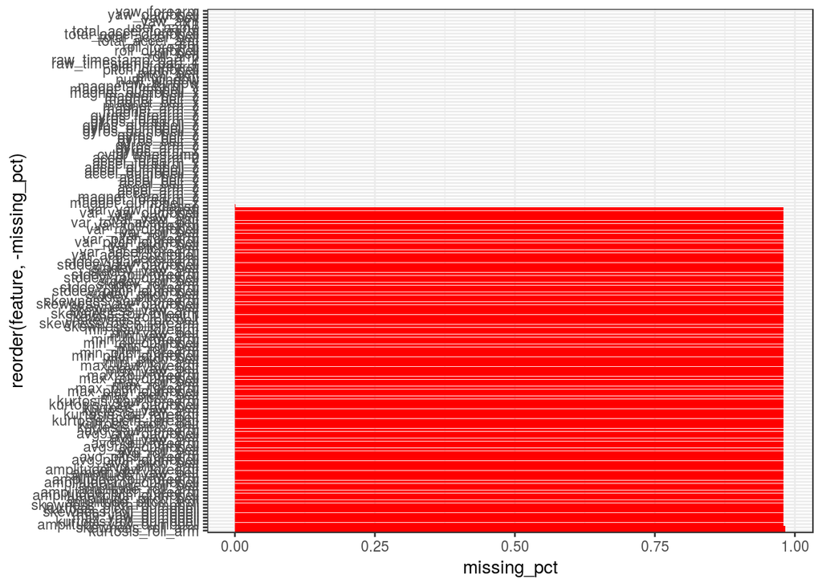

```r
# Check for Missing values
missing_values <- full %>% summarize_all(funs(sum(is.na(.))/n()))
missing_values <- gather(missing_values, key="feature", value="missing_pct")
# plot missing_pct
missing_values %>%
        ggplot(aes(x=reorder(feature,-missing_pct),y=missing_pct)) +
        geom_bar(stat="identity",fill="red") +
        coord_flip() +
        theme_bw()
```

#### 3.3.2 Remove features including more missings

Remove features percent greater than 90%

```r
missing_values_featues <- missing_values %>% filter(missing_pct >= 0.9) %>% pull(feature)
full_clean <- full %>% select(-missing_values_featues)
```

#### 3.3.3 Remove rows including less missings

Remove rows including less missings

```r
full_clean <- full_clean[complete.cases(full_clean), ]
anyNA(full_clean)
```

```
[1] FALSE
```

## 4. Feature engineering

Delete unrelated to prediction features:

```r
full_features <- full_clean %>%
        select(-c(X1, raw_timestamp_part_1, raw_timestamp_part_2, cvtd_timestamp))
```

## 5. Machine learning algorithm ~ Random Forest

```r
trainA <- full_features %>%
        filter(set == 'train') %>%
        mutate_at('classe', .funs = as.factor) %>%
        select(-set)
dim(trainA)
```

```
[1] 19621    56
```

### 5.2 Split training and testing from raw trainset

```r
inTrain <- createDataPartition(y=trainA$classe, p=0.75, list=FALSE)
training <- trainA[inTrain,]
testing <- trainA[-inTrain,]
dim(training);dim(testing)
```

```
[1] 14718    56
```

```
[1] 4903   56
```

```r
####check the proprtion of classe rate in orginal training data, current traing and testing data
round(prop.table(table(trainA$classe)*100),digits = 1)
```

```
  A   B   C   D   E
0.3 0.2 0.2 0.2 0.2
```

```r
round(prop.table(table(training$classe)*100),digits = 1)
```

```
  A   B   C   D   E
0.3 0.2 0.2 0.2 0.2
```

```r
round(prop.table(table(testing$classe)*100),digits = 1)
```

```
  A   B   C   D   E
0.3 0.2 0.2 0.2 0.2
```

### 5.3 Random Forest and Cross Validation

#### 5.3.1 Train Model

```r
set.seed(1234)
model_rf_down <- caret::train(classe ~ .,
                              data = training,
                              method = "rf",
                              # preProcess normalization before training
                              preProcess = c("scale", "center"),
                              # training control for cross validation: k=10, and repeat 2 times
                              trControl = trainControl(method = "repeatedcv",
                                                       number = 10,
                                                       repeats = 2,
                                                       savePredictions = TRUE,
                                                       verboseIter = FALSE,
                                                       sampling = "down"))
```

#### 5.3.2 Check and Visualize Model

Check model output:

```r
model_rf_down
```

```
Random Forest

14718 samples
   55 predictors
    5 classes: 'A', 'B', 'C', 'D', 'E'

Pre-processing: scaled (59), centered (59)
Resampling: Cross-Validated (10 fold, repeated 2 times)
Summary of sample sizes: 13248, 13246, 13249, 13246, 13246, 13245, ...
Addtional sampling using down-sampling prior to pre-processing

Resampling results across tuning parameters:

  mtry  Accuracy   Kappa
   2    0.9939528  0.9923509
  30    0.9969427  0.9961328
  59    0.9954484  0.9942431

Accuracy was used to select the optimal model using the largest value.
The final value used for the model was mtry = 30.
```

```r
model_rf_down$finalModel
```

```
Call:
 randomForest(x = x, y = y, mtry = param$mtry)
               Type of random forest: classification
                     Number of trees: 500
No. of variables tried at each split: 30

        OOB estimate of  error rate: 0.25%
Confusion matrix:
     A    B    C    D    E  class.error
A 2411    1    0    0    0 0.0004145937
B    6 2403    3    0    0 0.0037313433
C    0    4 2408    0    0 0.0016583748
D    0    0   11 2401    0 0.0045605307
E    0    0    0    5 2407 0.0020729685
```

Manual plot variable importance:

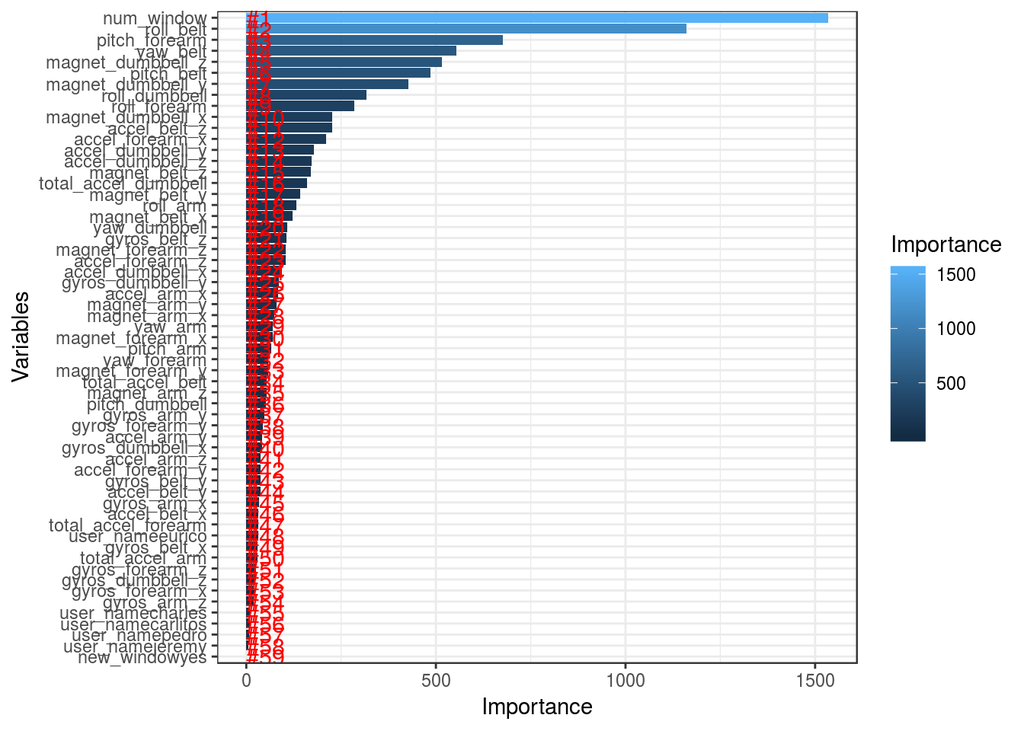

```r
##### Get importance
importance <- importance(model_rf_down$finalModel)
varImportance <- data.frame(Variables = row.names(importance),
                            Importance = round(importance[ ,'MeanDecreaseGini'],2))
##### Create a rank variable based on importance
rankImportance <- varImportance %>%
        mutate(Rank = paste0('#',dense_rank(desc(Importance))))
##### Use ggplot2 to visualize the relative importance of variables
ggplot(rankImportance, aes(x = reorder(Variables, Importance),
                           y = Importance, fill = Importance)) +
        geom_bar(stat='identity') +
        geom_text(aes(x = Variables, y = 0.5, label = Rank),
                  hjust=0, vjust=0.55, size = 4, colour = 'red') +
        labs(x = 'Variables') +
        coord_flip() +
        theme_bw()
```

Visual error curve:

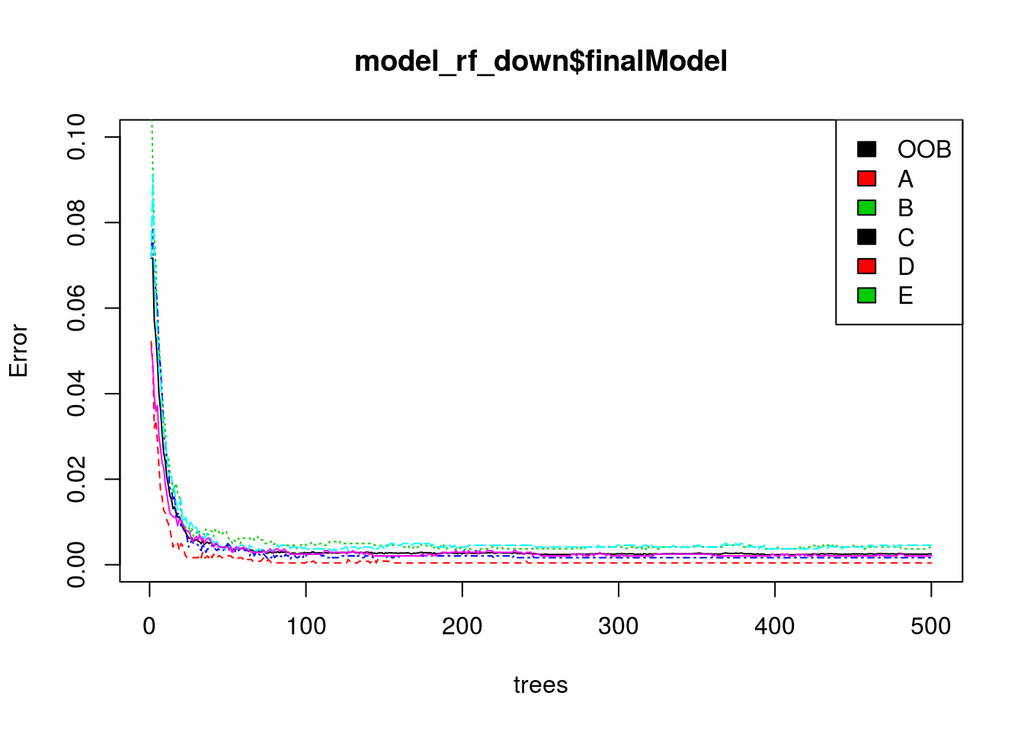

```r
plot(model_rf_down$finalModel, ylim=c(0,0.10))
legend('topright', colnames(model_rf_down$finalModel$err.rate), col=1:3, fill=1:3)
```

#### 5.3.2 Predict and Metrics

```r
predicter <- predict(model_rf_down, newdata = testing)
confusionMatrix(predicter, as.factor(testing$classe))
```

```
Confusion Matrix and Statistics

          Reference
Prediction    A    B    C    D    E
         A 1393    2    0    0    0
         B    0  947    2    0    0
         C    0    0  853    1    0
         D    0    0    0  803    5
         E    1    0    0    0  896

Overall Statistics

               Accuracy : 0.9978
                 95% CI : (0.996, 0.9989)
    No Information Rate : 0.2843
    P-Value [Acc > NIR] : < 2.2e-16

                  Kappa : 0.9972
 Mcnemar's Test P-Value : NA

Statistics by Class:

                     Class: A Class: B Class: C Class: D Class: E
Sensitivity            0.9993   0.9979   0.9977   0.9988   0.9945
Specificity            0.9994   0.9995   0.9998   0.9988   0.9998
Pos Pred Value         0.9986   0.9979   0.9988   0.9938   0.9989
Neg Pred Value         0.9997   0.9995   0.9995   0.9998   0.9988
Prevalence             0.2843   0.1936   0.1744   0.1640   0.1838
Detection Rate         0.2841   0.1931   0.1740   0.1638   0.1827
Detection Prevalence   0.2845   0.1936   0.1742   0.1648   0.1829
Balanced Accuracy      0.9994   0.9987   0.9987   0.9988   0.9971
```